# Projet Info-Stat UE MI0A403T

Bensmaine Yacine (25%), Kessaci Bilel (25%), Khelouat Amine (25%), Zouaoui Mohamed Elmehdi(25%)

2024-2025

# 1 Diagramme d’activités

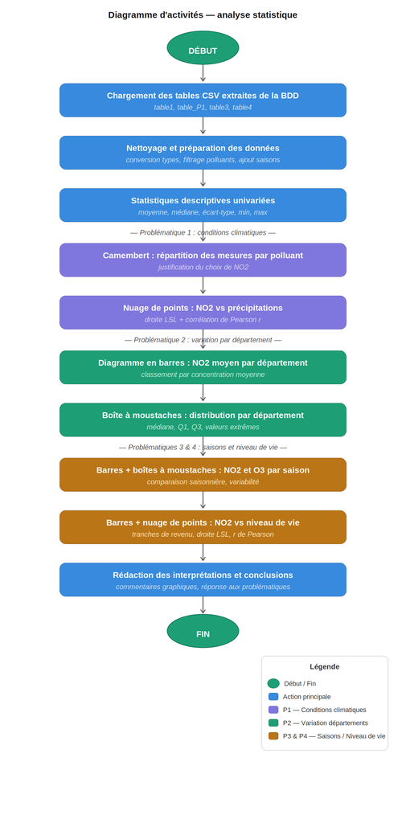

Diagramme d’activités — analyse statistique

# 2 Base de données

## 2.1 Construction de la base de données

Ce projet porte sur l’étude de la pollution de l’air en Occitanie. Les données nous ont été fournies sous la forme de trois fichiers CSV :

- **mesures_occitanie_journaliere_pollution.csv** : 231 843 mesures journalières de 8 polluants (NO, NO2, NOX, O3, PM10, PM2.5, SO2, H2S) relevées dans 36 communes d’Occitanie entre 2022 et 2026.
- **donnees_geo_climatiques.csv** : données géographiques et climatiques (température, vent, précipitations, insolation, altitude…) pour 34 935 communes françaises.
- **donnees_socio_economiques.csv** : données socio-économiques (niveau de vie médian, population, pourcentage d’appartements…) pour 34 875 communes françaises.

Nous avons construit la base de données en Python à l’aide des bibliothèques **pandas** et **sqlite3**, via le script `creation_bdd.py`. La construction suit quatre étapes successives.

### 2.1.1 Étape 1 — Lecture des fichiers CSV

Les trois fichiers CSV sont chargés en mémoire avec `pandas.read_csv()`. On obtient trois DataFrames :

```python
df_pollution = pd.read_csv("mesures_occitanie_journaliere_pollution.csv")
df_geo       = pd.read_csv("donnees_geo_climatiques.csv", low_memory=False)
df_socio     = pd.read_csv("donnees_socio_economiques.csv")
```

Le paramètre `low_memory=False` est nécessaire pour le fichier géographique car certaines colonnes contiennent des types mixtes.

### 2.1.2 Étape 2 — Harmonisation des codes INSEE

Un problème de type a été identifié : dans le fichier de pollution, le champ `code_insee_com` est stocké en entier (`int`), alors que dans les deux autres fichiers il est stocké en texte (`str`). Cette différence aurait empêché les jointures SQL de fonctionner. Nous avons donc converti toutes les colonnes en `Int64` avec `pd.to_numeric()` :

```python
df_pollution['code_insee_com'] = pd.to_numeric(
    df_pollution['code_insee_com'], errors='coerce'
).astype('Int64')
# idem pour df_geo et df_socio
```

Une vérification a ensuite confirmé que les 36 codes communes de pollution sont bien présents dans les deux autres fichiers.

### 2.1.3 Étape 3 — Insertion dans la base SQLite

Une base de données SQLite est créée et les trois DataFrames sont insérés comme tables avec `to_sql()` :

```python
conn = sqlite3.connect("bdd_pollution_occitanie.db")
df_pollution.to_sql("mesures_pollution",       conn, if_exists="replace", index=False)
df_geo.to_sql("donnees_geo_climatiques",       conn, if_exists="replace", index=False)
df_socio.to_sql("donnees_socio_economiques",   conn, if_exists="replace", index=False)
```

Le paramètre `if_exists="replace"` permet de recréer la table si le script est relancé.

### 2.1.4 Étape 4 — Extraction des tables d’analyse par requêtes SQL

Cinq tables ont été extraites via `pd.read_sql_query()` et exportées en CSV pour être utilisées dans R :

| Table CSV | Contenu | Utilisée pour |
| --- | --- | --- |
| `table_analyse_univariee.csv` | Statistiques descriptives globales par polluant | Étude univariée |
| `table_stats_par_commune_polluant.csv` | Statistiques descriptives par commune et polluant | Répartition des mesures par polluant (appui Problématique 1) |
| `table_climat_pollution.csv` | Mesures journalières + variables climatiques (jointure) | Problématique 1 |
| `table_pollution_par_departement.csv` | Concentrations mensuelles agrégées par département | Problématiques 2 et 3 |
| `table_pollution_socioeco.csv` | Concentrations + données socio-économiques (jointure) | Problématique 4 |

**Polluants exclus** : SO2 (3 067 mesures, 2 communes) et H2S (3 061 mesures, 2 communes) sont trop peu représentés pour être analysés de façon fiable. Les analyses portent donc sur les **6 polluants principaux** : NO, NO2, NOX, O3, PM10, PM2.5.

## 2.2 Requêtes SQL pour chaque problématique

### 2.2.1 Table pour la Problématique 1 — Climat et pollution

Cette table est construite par une **jointure LEFT JOIN** entre les mesures de pollution et les données géo-climatiques sur `code_insee_com`. Elle conserve toutes les mesures journalières et y ajoute les variables climatiques (précipitations, vent, température…) de la commune correspondante :

```sql
SELECT
    p.nom_dept, p.nom_com, p.code_insee_com,
    p.nom_poll AS polluant, p.valeur_poll AS concentration,
    p.jour, p.mois, p.annee,
    g.Force_vent_med  AS force_vent,
    g.RR_med          AS precipitations,
    g.Tmin_med        AS temperature_min,
    g.Tmax_med        AS temperature_max
FROM mesures_pollution p
LEFT JOIN donnees_geo_climatiques g
    ON p.code_insee_com = g.code_insee_com
ORDER BY p.nom_com, p.nom_poll, p.annee, p.mois, p.jour
```

### 2.2.2 Table pour les Problématiques 2 et 3 — Départements et saisons

```sql
SELECT
    p.nom_dept, p.nom_poll AS polluant,
    p.annee, p.mois,
    ROUND(AVG(p.valeur_poll), 2) AS conc_moyenne,
    ROUND(MIN(p.valeur_poll), 2) AS conc_min,
    ROUND(MAX(p.valeur_poll), 2) AS conc_max,
    COUNT(*) AS nb_mesures
FROM mesures_pollution p
GROUP BY p.nom_dept, p.code_insee_com, p.nom_poll, p.annee, p.mois
ORDER BY p.nom_dept, p.nom_poll, p.annee, p.mois
```

### 2.2.3 Table pour la Problématique 4 — Niveau de vie et pollution

Cette table combine les mesures de pollution avec les données socio-économiques via une **jointure LEFT JOIN**, puis agrège par commune et polluant pour obtenir une concentration moyenne par commune :

```sql
SELECT
    p.nom_dept, p.nom_com, p.code_insee_com,
    p.nom_poll AS polluant,
    ROUND(AVG(p.valeur_poll), 2) AS conc_moyenne,
    s.niveau_vie_median_2021     AS niveau_vie,
    s.population_municipale_2023 AS population
FROM mesures_pollution p
LEFT JOIN donnees_socio_economiques s
    ON p.code_insee_com = s.code_insee_com
GROUP BY p.code_insee_com, p.nom_poll
ORDER BY p.nom_com, p.nom_poll
```

# 3 Statistique descriptive

## 3.1 Identification de problématiques statistiques

À partir des données disponibles, nous avons identifié quatre problématiques statistiques :

**Problématique 1** : Les conditions climatiques (précipitations, vent) influencent-elles les concentrations de polluants en Occitanie ?

**Problématique 2** : Les niveaux de pollution diffèrent-ils d’un département à l’autre en Occitanie ?

**Problématique 3** : Les concentrations de polluants varient-elles selon les saisons ?

**Problématique 4** : Existe-t-il un lien entre le niveau de vie des communes et leur niveau de pollution ?

## 3.2 Étude univariée des polluants

### 3.2.1 Chargement des données

```r
# Chargement de la table d'analyse univariée
df_univariate <- read.csv("table_analyse_univariee.csv")

# Polluants à étudier
polluants_ok <- c("NO", "NO2", "NOX", "O3", "PM10", "PM2.5")

# Filtrer sur les polluants principaux
df_univariate <- df_univariate %>% filter(polluant %in% polluants_ok)
```

### 3.2.2 Tableau récapitulatif des statistiques descriptives

Le tableau ci-dessous présente pour chaque polluant les statistiques descriptives fondamentales :

```r
df_univariate %>%
  select(polluant, nb_observations, moyenne, minimum, maximum, ecart_type,
         nb_communes, nb_stations, nb_annees) %>%
  rename(
    "Polluant" = polluant,
    "N observations" = nb_observations,
    "Moyenne" = moyenne,
    "Min" = minimum,
    "Max" = maximum,
    "Écart-type" = ecart_type,
    "Communes" = nb_communes,
    "Stations" = nb_stations,
    "Années" = nb_annees
  ) %>%
  knitr::kable(
    caption = "Statistiques descriptives par polluant (Occitanie 2022-2026)",
    align = "lccccccc",
    format = "html"
  ) %>%
  kableExtra::kable_styling(bootstrap_options = c("striped", "hover"))
```

Statistiques descriptives par polluant (Occitanie 2022-2026)

| Polluant | N observations | Moyenne | Min | Max | Écart-type | Communes | Stations | Années |
| --- | --- | --- | --- | --- | --- | --- | --- | --- |
| NO | 31542 | 12.46 | -1.1 | 231.4 | 24.03 | 21 | 37 | 5 |
| NO2 | 48014 | 16.75 | -0.7 | 97.3 | 16.57 | 22 | 42 | 5 |
| NOX | 42239 | 35.93 | 0.0 | 438.0 | 45.09 | 21 | 37 | 5 |
| O3 | 44529 | 57.48 | 2.9 | 139.5 | 37.55 | 25 | 28 | 5 |
| PM10 | 27286 | 14.58 | 0.4 | 209.8 | 14.40 | 24 | 38 | 5 |
| PM2.5 | 32105 | 8.57 | 0.3 | 59.2 | 18.19 | 23 | 32 | 5 |

### 3.2.3 Visualisations univariées

#### 3.2.3.1 Graphique 1 — Concentration moyenne par polluant

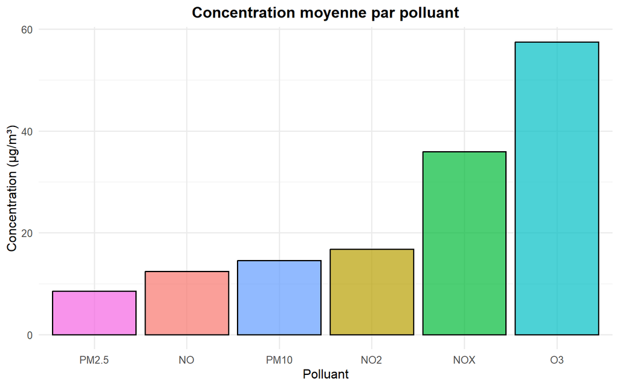

```r
df_univariate %>%
  ggplot(aes(x = reorder(polluant, moyenne), y = moyenne, fill = polluant)) +
  geom_col(alpha = 0.7, color = "black") +
  labs(
    title = "Concentration moyenne par polluant",
    x = "Polluant", y = "Concentration (µg/m³)",
    fill = "Polluant"
  ) +
  theme_minimal(base_size = 12) +
  theme(
    plot.title = element_text(face = "bold", hjust = 0.5),
    legend.position = "none"
  )
```